# Graphs_plots

Nemutshili Ndivho

2024-10-21

Here’s a Markdown document for the provided R script, including an introduction and explanation of each section:

# Data Visualization Script for Cellular Automata and Scatter Plots

This document outlines an R script designed for visualizing data related to cellular automata and scatter plots. The script utilizes several libraries to create informative plots from the provided dataset. The visualization aims to enhance understanding of various cellular parameters and their interrelations.

## ──────────────────────────────────────────────────────────────────────────────

## ──────────────────────────────────────────────────────────────────────────────

### Section 1: Load Necessary Libraries

```r
library(ggplot2)
library(dplyr)
library(tidyr)  # For data manipulation
library(patchwork)  # For combining plots
```

In this section, the necessary libraries are loaded. `ggplot2` is used for plotting, `dplyr` for data manipulation, `tidyr` for tidying data, and `patchwork` for combining multiple plots.

### Section 2: Load Data

```r
data_file <- "./Output_results.csv"
data <- read.csv(data_file)
```

The script defines the file path for the dataset and loads it into a data frame called `data`.

### Section 3: Define a Scatter Plot Function

```r
plot_scatter <- function(x_var, y_var, x_unit = "", y_unit = "") {
  ggplot(data, aes_string(x = x_var, y = y_var)) +
    geom_point(color = "#FF6F61", fill = "#FFABAB", size = 2, shape = 21, stroke = 0.8) +
    labs(x = paste(x_var, x_unit), y = paste(y_var, y_unit)) +
    theme_minimal(base_size = 10) +
    theme(axis.title = element_text(size = 9),
          axis.text = element_text(size = 8),
          plot.title = element_text(size = 10))
}
```

A function called `plot_scatter` is defined to create scatter plots. It takes variable names and optional units for the x and y axes, using `ggplot2` to create and style the plots.

### Section 4: Define Units for Variables

```r
units_dict <- list(
  "AuxinConc" = "(mol/m^3)",
  "AuxinPeak" = "(mol/m^3)",
  "DaysSinceCZExit" = "(days)",
  "AuxConcChangeRate" = "(mol/day)",
  "DaysSinceSecThickening" = "(days)",
  "CellVolume" = "(m^3)",
  "LumenVolume" = "(m^3)",
  "AverageLumenVolume" = "(m^3)",
  "CellWallThickness" = "(m)",
  "CambiumWidth" = "(m)",
  "CellLength" = "(m)",
  "AverageCellVolume" = "(m^3)",
  "CritCellCycleDuration" = "(days)",
  "CellWallCSArea" = "(m^2)",
  "CellWallCSArea0" = "(m^2)",
  "ConductingXylemPosition" = "(unitless)",
  "CellCSArea" = "(m^2)",
  "CellRD" = "(m)",
  "CellTD" = "(m)"
)
```

A dictionary of units for different variables is created, which will be used when labeling the axes of the scatter plots.

### Section 5: Define Pairs of Variables to Plot

```r
plot_pairs <- list(
  c("AuxinConc", "DaysSinceCZExit"),
  c("AuxConcChangeRate", "DaysSinceSecThickening"),
  c("CellVolume", "AuxinConc"),
  c("LumenVolume", "DaysSinceSecThickening"),
  c("CellWallThickness", "DaysSinceSecThickening"),
  c("CambiumWidth", "DaysSinceCZExit"),
  c("CellLength", "AuxinConc"),
  c("AverageCellVolume", "CritCellCycleDuration"),
  c("CellWallCSArea", "AuxinConc"),
  c("CellWallCSArea0", "CellWallThickness"),
  c("CellLength", "DaysSinceCZExit"),
  c("AverageLumenVolume", "DaysSinceCZExit"),
  c("ConductingXylemPosition", "CambiumWidth"),
  c("LumenVolume", "CellWallThickness"),
  c("CellCSArea", "DaysSinceSecThickening")
)
```

This section defines pairs of variables to be plotted against each other, facilitating the generation of multiple scatter plots.

### Section 6: Create Output Directory

```r
dir.create("markdown_plots", showWarnings = FALSE)
```

A directory named “markdown_plots” is created to store the generated scatter plots.

### Section 7: Generate Scatter Plots

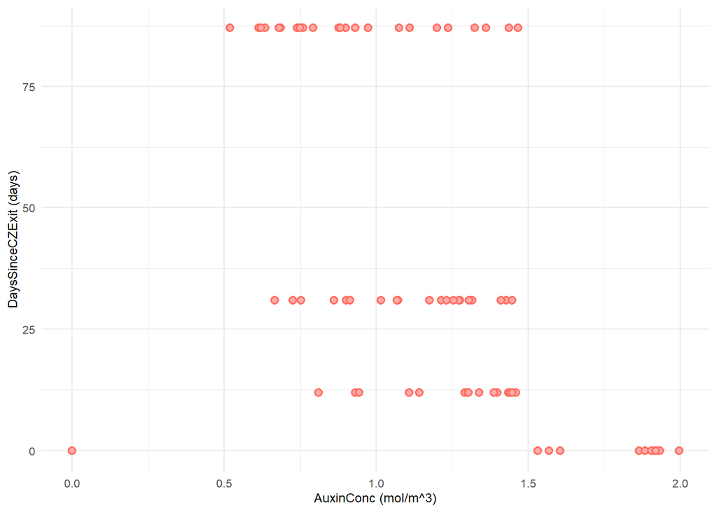

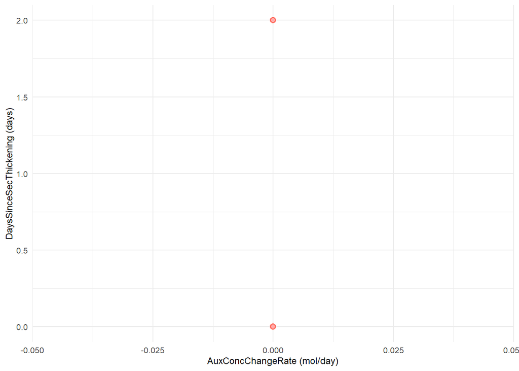

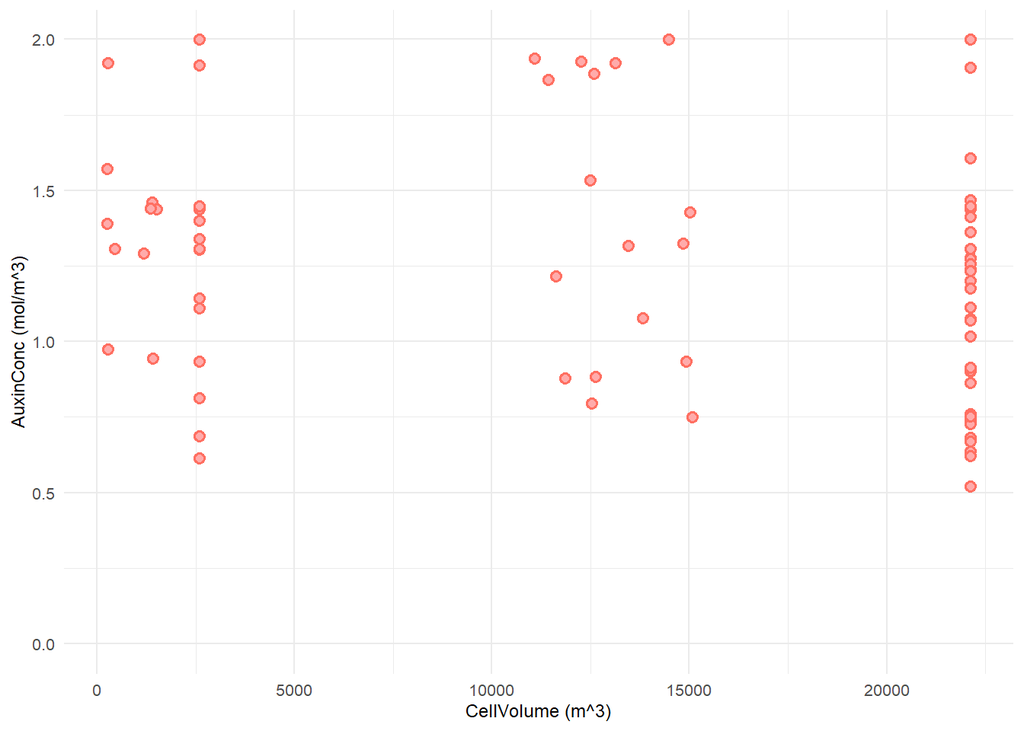

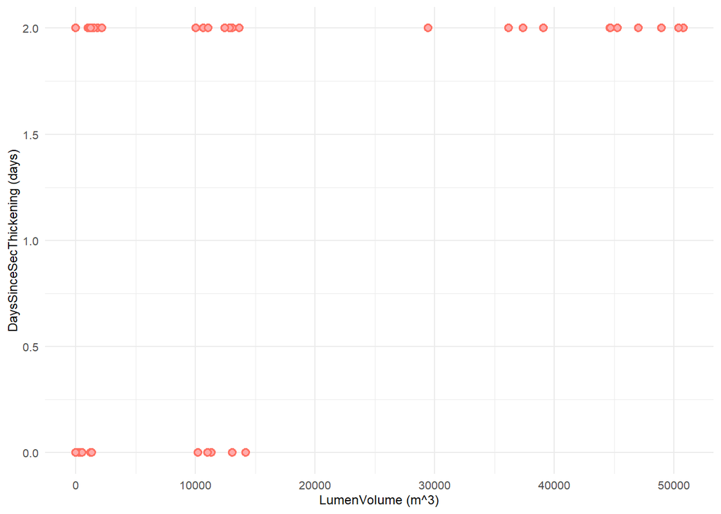

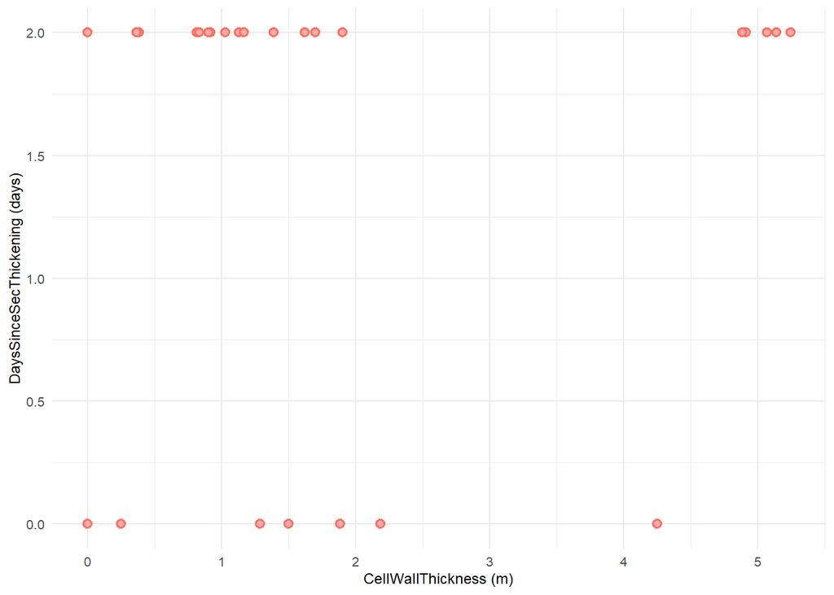

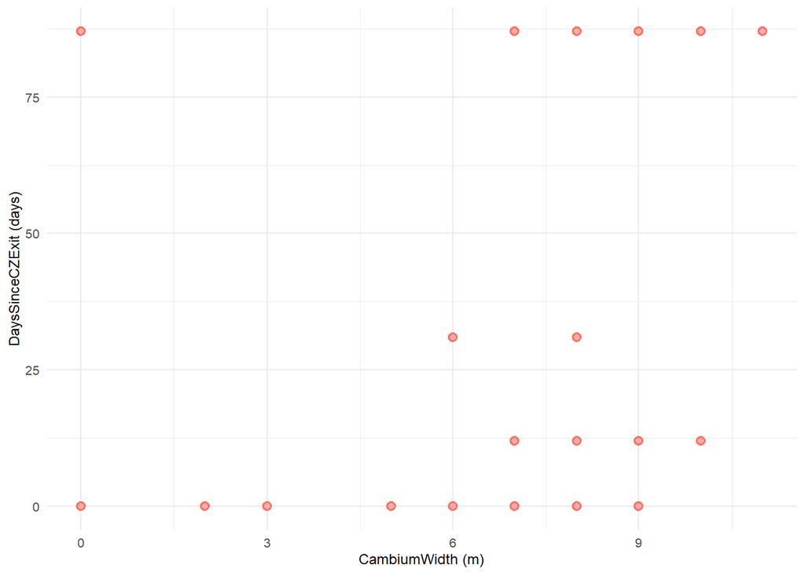

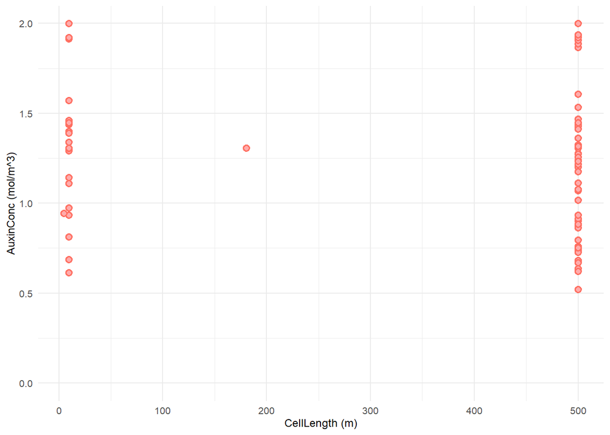

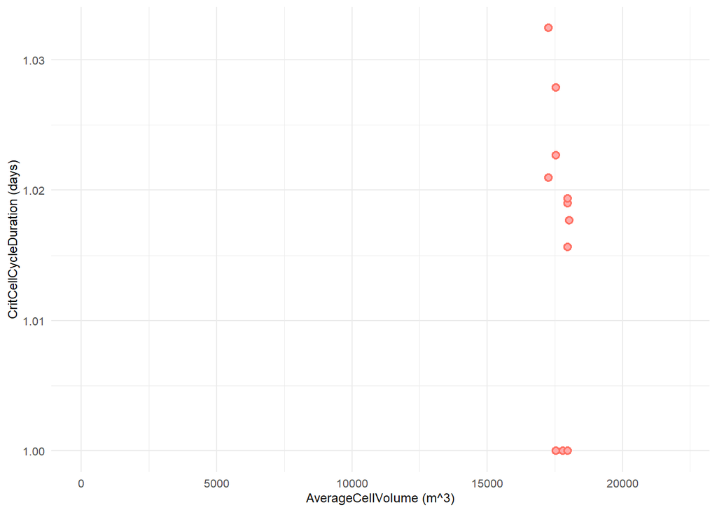

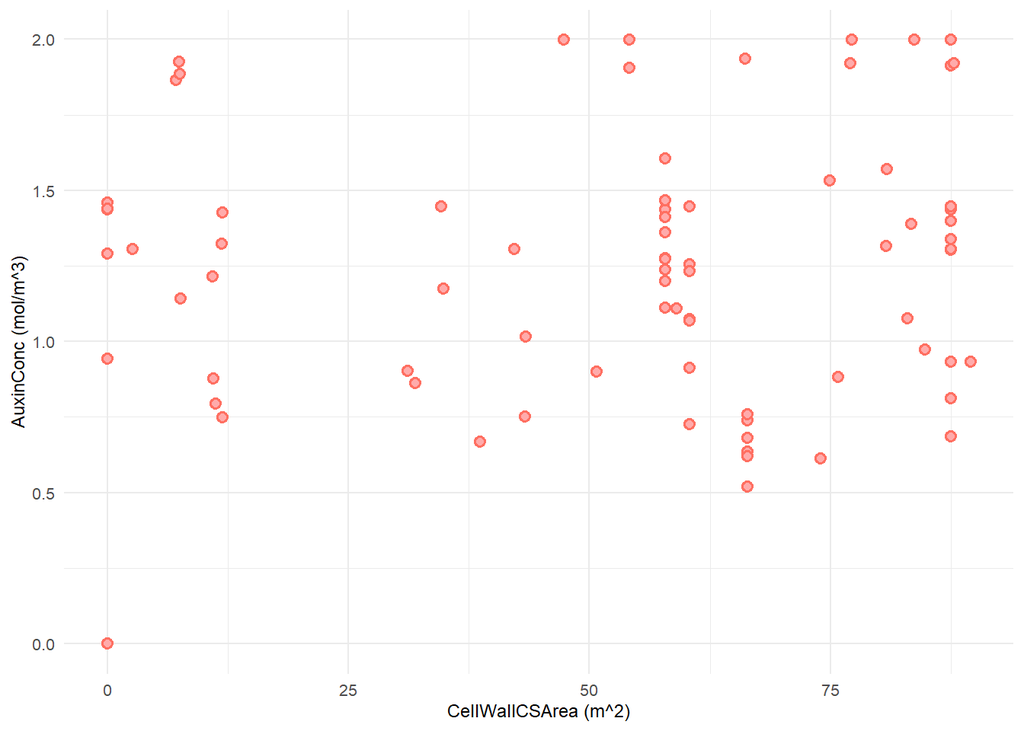

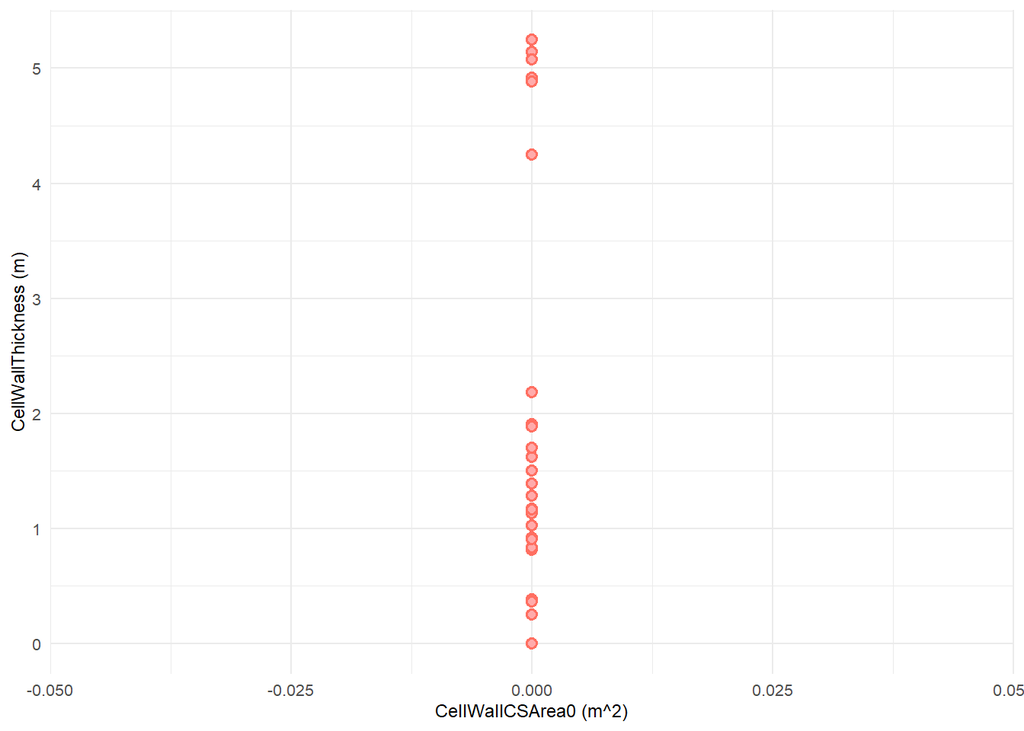

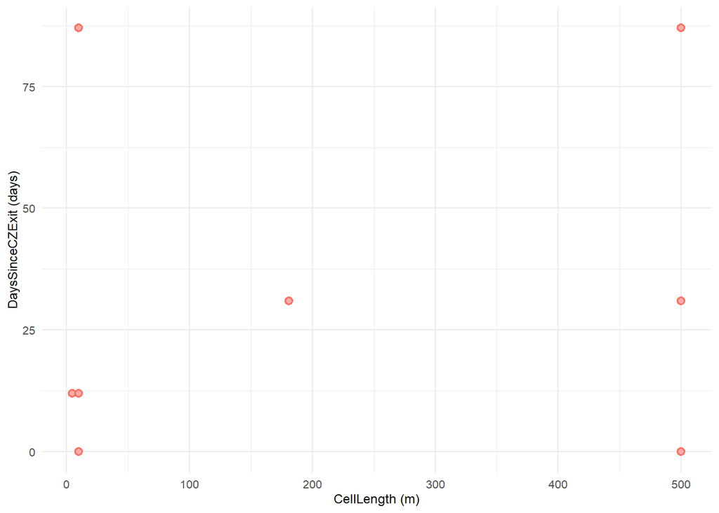

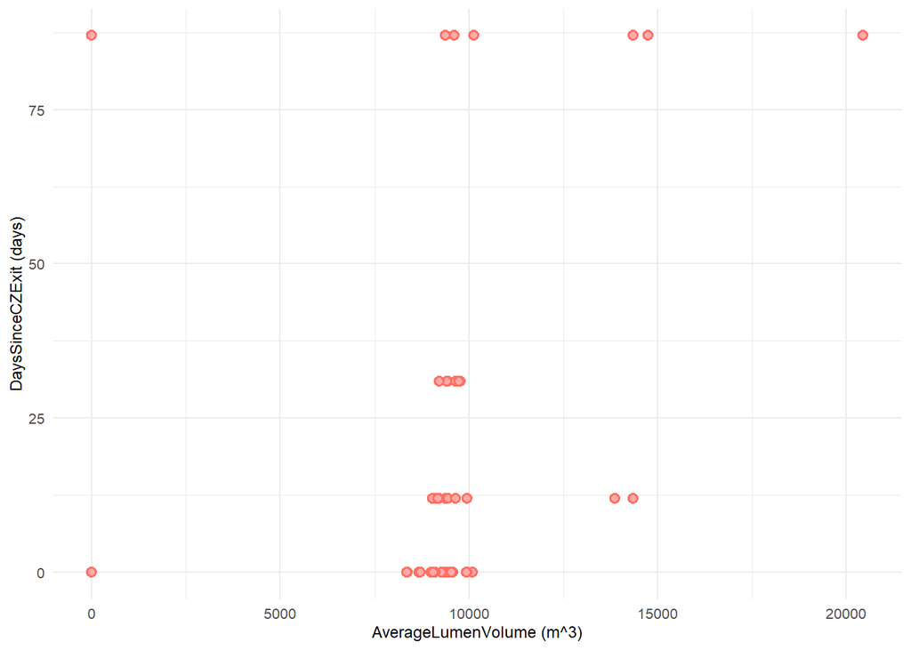

[3 more figures not shown]

```r
for (pair in plot_pairs) {
  x_var <- pair[1]
  y_var <- pair[2]

  x_unit <- units_dict[[x_var]] %||% ""
  y_unit <- units_dict[[y_var]] %||% ""

  scatter_plot <- plot_scatter(x_var, y_var, x_unit, y_unit)

  # Print the plot in HTML
  print(scatter_plot)

  # Save the plot as PNG
  ggsave(filename = paste0("markdown_plots/scatter_", x_var, "_vs_", y_var, ".png"), plot = scatter_plot)
}
```

### Section 8: Plotting Mean CellRD and CellTD per Day

```r
mean_cellRD_cellTD_per_day <- data %>%
  group_by(DaysSinceCZExit) %>%
  summarize(mean_cellRD = mean(cellRD, na.rm = TRUE),
            mean_cellTD = mean(cellTD, na.rm = TRUE)) %>%
  drop_na()
```

This section calculates the mean values of `cellRD` and `cellTD` for each day since cambium zone exit, excluding any missing values.

### Section 9: Create Scatter Plots for Mean Values

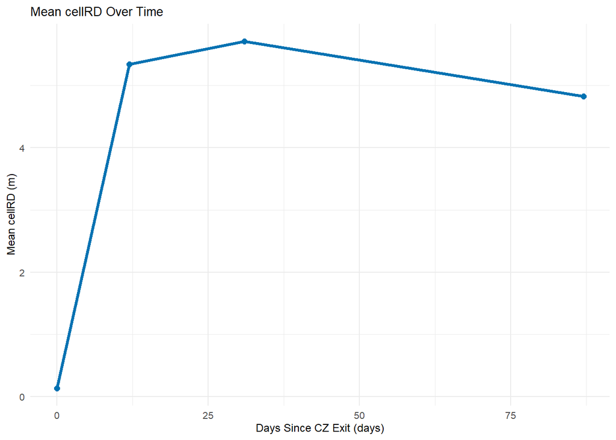

```r
# Create scatter plot for mean cellRD
plot_mean_cellRD <- ggplot(mean_cellRD_cellTD_per_day, aes(x = DaysSinceCZExit, y = mean_cellRD)) +
  geom_point(color = "#0072B2", size = 2) +
  geom_line(color = "#0072B2", linewidth = 1.2) +
  labs(x = "Days Since CZ Exit (days)", y = "Mean cellRD (m)", title = "Mean cellRD Over Time") +
  theme_minimal(base_size = 10) +
  theme(axis.title = element_text(size = 9),
        axis.text = element_text(size = 8),
        plot.title = element_text(size = 10))

# Print the mean cellRD plot
print(plot_mean_cellRD)
```

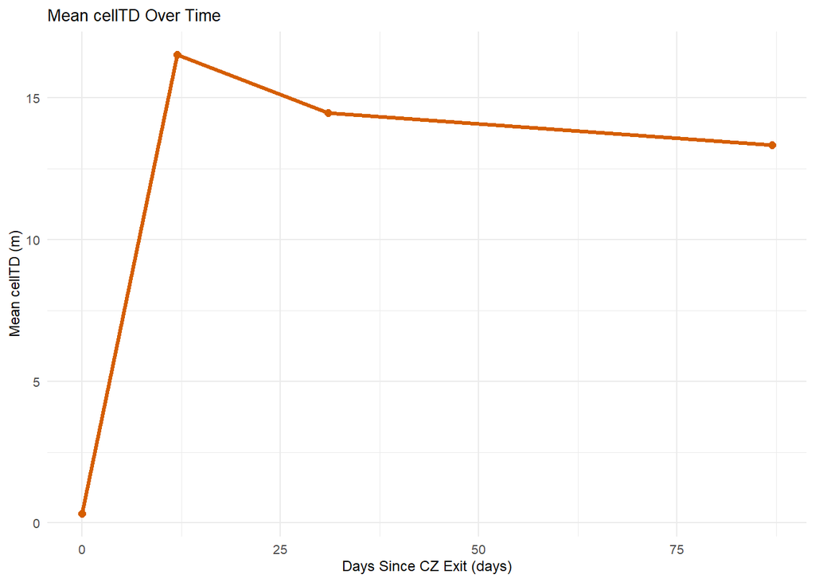

```r
# Create scatter plot for mean cellTD
plot_mean_cellTD <- ggplot(mean_cellRD_cellTD_per_day, aes(x = DaysSinceCZExit, y = mean_cellTD)) +
  geom_point(color = "#D55E00", size = 2) +
  geom_line(color = "#D55E00", linewidth = 1.2) +
  labs(x = "Days Since CZ Exit (days)", y = "Mean cellTD (m)", title = "Mean cellTD Over Time") +
  theme_minimal(base_size = 10) +
  theme(axis.title = element_text(size = 9),
        axis.text = element_text(size = 8),
        plot.title = element_text(size = 10))

# Print the mean cellTD plot
print(plot_mean_cellTD)
```

Two scatter plots are created for the mean values of `cellRD` and `cellTD` over time, with lines connecting the points for clarity.

### Section 10: Combine and Save Mean Plots

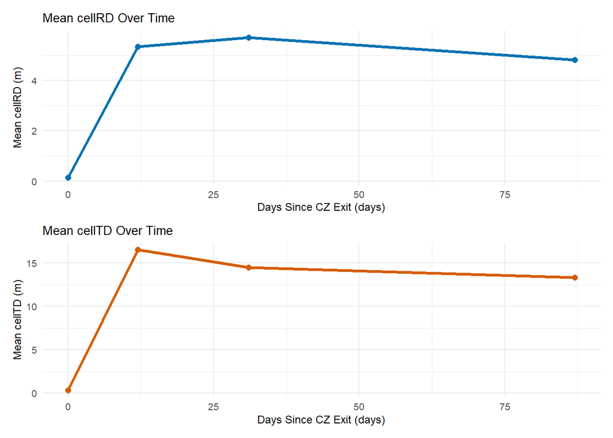

```r
combined_plot <- plot_mean_cellRD / plot_mean_cellTD
print(combined_plot)
```

```r
ggsave(filename = "markdown_plots/mean_cellRD_cellTD_combined.png", plot = combined_plot)
```

The two mean plots are combined vertically and saved as a single image file.

## ──────────────────────────────────────────────────────────────────────────────

## Cellular Automata Plot Script

## ──────────────────────────────────────────────────────────────────────────────

### Section 1: Load Necessary Libraries

```r
library(ggplot2)
library(RColorBrewer)
library(gridExtra) # For arranging plots
library(patchwork) # For combining plots
```

Similar to the previous section, libraries for plotting and arranging plots are loaded.

### Section 2: Read Data

```r
data_file <- read.csv("./Output_results.csv")
```

The dataset is read into a new variable `data_file`.

### Section 3: Create Output Directory

```r
if (!dir.exists("markdown_plots")) {
  dir.create("markdown_plots")
}
```

A new directory named “markdown_plots” is created if it does not already exist to store the cellular automata plots.

### Section 4: Define Color Palette

```r
cell_type_colors <- brewer.pal(n = length(unique(data_file$CellType)), "Set3")
```

A color palette for different cell types is created using the `RColorBrewer` package.

### Section 5: Generate Plots

#### Subsection 5.1: Cell Type Only

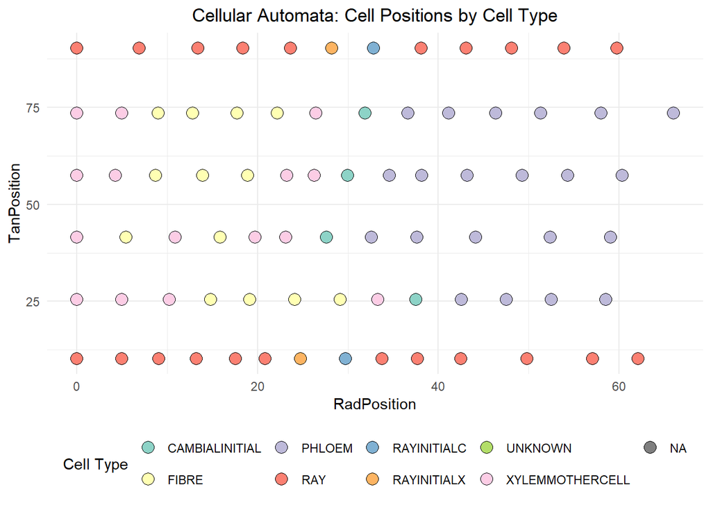

```r
plot1 <- ggplot(data_file, aes(x = RadPosition, y = TanPosition, fill = as.factor(CellType))) +
  geom_point(shape = 21, color = "black", size = 4, stroke = 0.3) +
  scale_fill_manual(values = cell_type_colors) +
  labs(title = "Cellular Automata: Cell Positions by Cell Type", fill = "Cell Type") +
  theme_minimal() +
  theme(
    plot.title = element_text(hjust = 0.5),
    legend.position = "bottom"
  )

# Print the cell type position plot
print(plot1)
```

A scatter plot is created to show cellular positions based on cell types, using the defined color palette.

#### Subsection 5.2: Cell Wall thickness Only

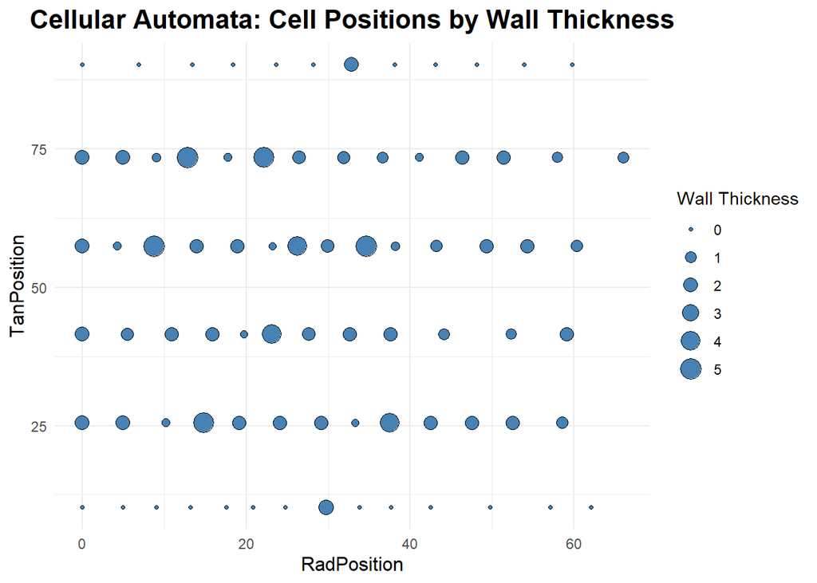

```r
plot2 <- ggplot(data_file, aes(x = RadPosition, y = TanPosition, size = CellWallThickness)) +
  geom_point(shape = 21, fill = "steelblue", color = "black", stroke = 0.3) + # Points in blue with size as thickness
  labs(title = "Cellular Automata: Cell Positions by Wall Thickness", size = "Wall Thickness") +
  theme_minimal() +
  theme(
    plot.title = element_text(hjust = 0.5, size = 16, face = "bold"),
    axis.title.x = element_text(size = 12),
    axis.title.y = element_text(size = 12)
  )

# Print Plot 2
print(plot2)
```

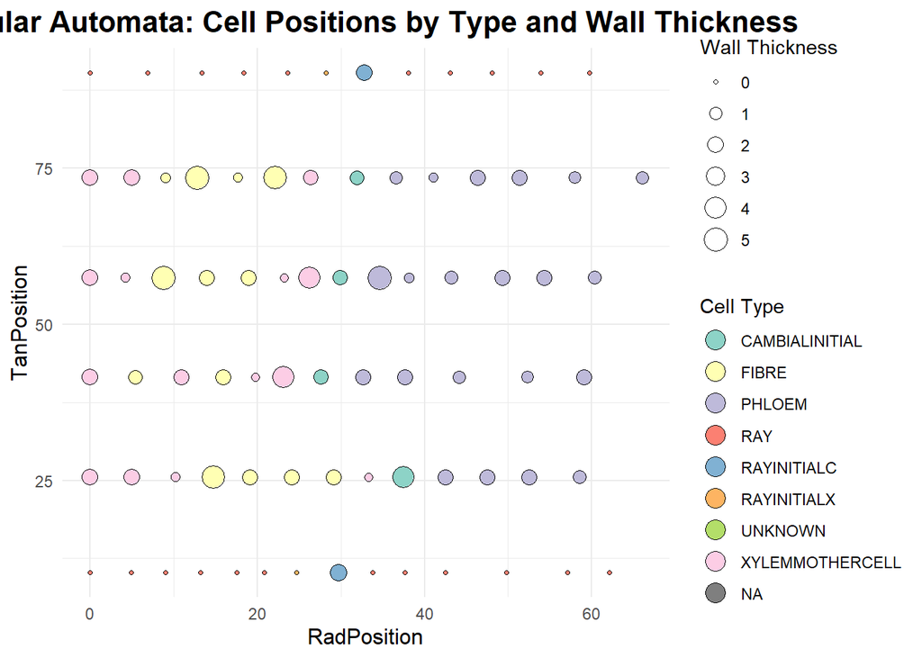

```r
plot3 <- ggplot(data_file, aes(x = RadPosition, y = TanPosition,
                               fill = as.factor(CellType), size = CellWallThickness)) +
  geom_point(shape = 21, color = "black", stroke = 0.3) + # Points with both fill and size
  scale_fill_manual(values = cell_type_colors) + # Apply the color palette to cell types
  labs(title = "Cellular Automata: Cell Positions by Type and Wall Thickness",
       fill = "Cell Type", size = "Wall Thickness") +
  theme_minimal() +
  theme(
    plot.title = element_text(hjust = 0.5, size = 16, face = "bold"),
    axis.title.x = element_text(size = 12),
    axis.title.y = element_text(size = 12)
  ) +
  guides(fill = guide_legend(override.aes = list(size = 5))) # Make legend dots bigger for clarity

# Print Plot 3
print(plot3)
```

### Section 6: Save Cellular Automata Plots

```r
ggsave(filename = "markdown_plots/cellular_automata_cell_positions.png", plot = plot1)
ggsave(filename = "markdown_plots/cellular_automata_cell_wall_thickness.png", plot = plot2)
ggsave(filename = "markdown_plots/combined_cell_type_thickness.png", plot = plot3)
```

The cellular automata plots are saved in the specified directory.

Here’s your R script organized into sections with numbered titles for easy reference in a markdown document:

## ──────────────────────────────────────────────────────────────────────────────

## PNG 2D

## ──────────────────────────────────────────────────────────────────────────────

## Section 1: Load Necessary Libraries

```r
library(ggplot2)
library(rayshader)
```

## Section 2: Define File Path and Load Data

```r
# Define the file path for the data (change this to your file path)
data_file <- "./Output_results.csv"

# Load the data from a CSV file into a data frame
data <- read.csv(data_file)  # If your file is CSV
```

## Section 3: Create Directory for Custom Plots

```r
# Create directory for custom plots
dir.create("markdown_plots", showWarnings = FALSE)
```

## Section 4: Updated Units Dictionary

```r
# Updated Units dictionary
units_dict <- list(
  "AuxinConc" = "(mol/m^3)",
  "AuxinPeak" = "(mol/m^3)",
  "DaysSinceCZExit" = "(days)",
  "AuxConcChangeRate" = "(mol/day)",
  "DaysSinceSecThickening" = "(days)",
  "CellVolume" = "(m^3)",
  "LumenVolume" = "(m^3)",
  "AverageLumenVolume" = "(m^3)",
  "CellWallThickness" = "(m)",
  "CambiumWidth" = "(m)",
  "CellLength" = "(m)",
  "AverageCellVolume" = "(m^3)",
  "CritCellCycleDuration" = "(days)",
  "CellWallCSArea" = "(m^2)",
  "CellWallCSArea0" = "(m^2)",
  "ConductingXylemPosition" = "(unitless)",
  "CellCSArea" = "(m^2)",
  "CellRD" = "(m)",
  "CellTD" = "(m)"
)
```

## Section 5: Define Pairs to Plot

```r
# Pairs to plot
plot_pairs <- list(
  c("AuxinConc", "DaysSinceCZExit"),
  c("AuxConcChangeRate", "DaysSinceSecThickening"),
  c("CellVolume", "AuxinConc"),
  c("LumenVolume", "DaysSinceSecThickening"),
  c("CellWallThickness", "DaysSinceSecThickening"),
  c("CambiumWidth", "DaysSinceCZExit"),
  c("CellLength", "AuxinConc"),
  c("AverageCellVolume", "CritCellCycleDuration"),
  c("CellWallCSArea", "AuxinConc"),
  c("CellWallCSArea0", "CellWallThickness"),
  c("CellLength", "DaysSinceCZExit"),
  c("AverageLumenVolume", "DaysSinceCZExit"),
  c("ConductingXylemPosition", "CambiumWidth"),
  c("LumenVolume", "CellWallThickness"),
  c("CellCSArea", "DaysSinceSecThickening")
)
```

## Section 6: Loop Through Each Pair and Create PNG Images

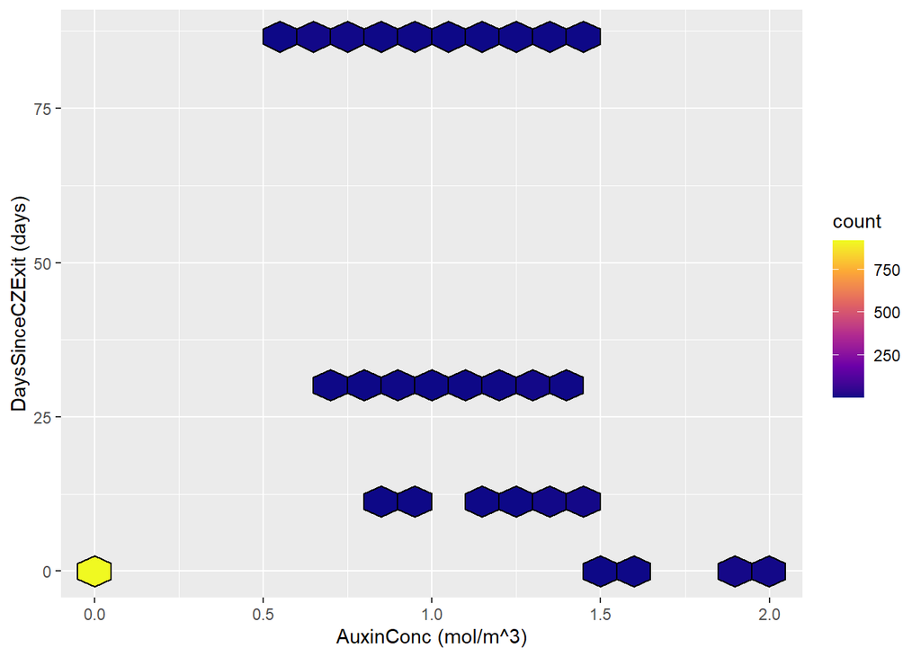

[figure not shown]

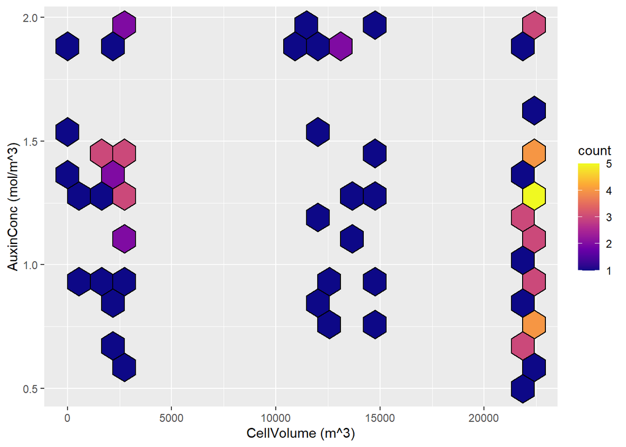

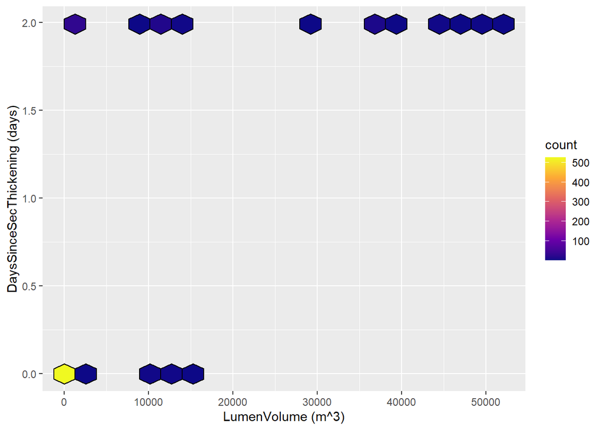

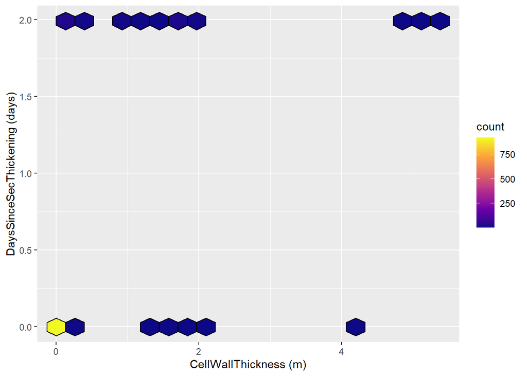

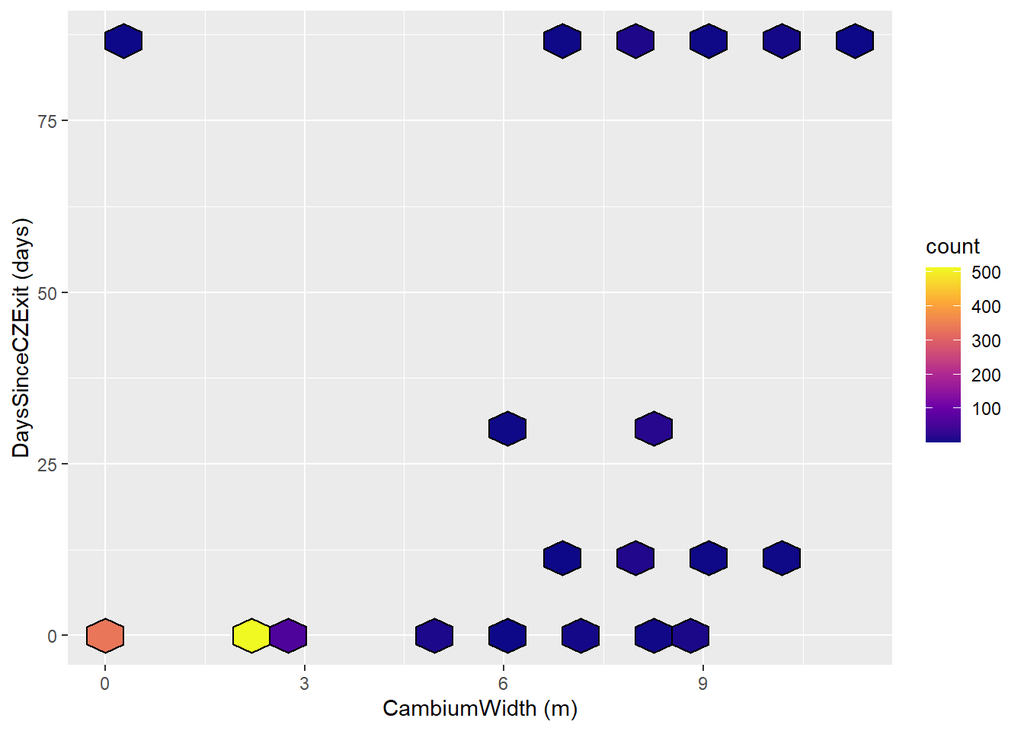

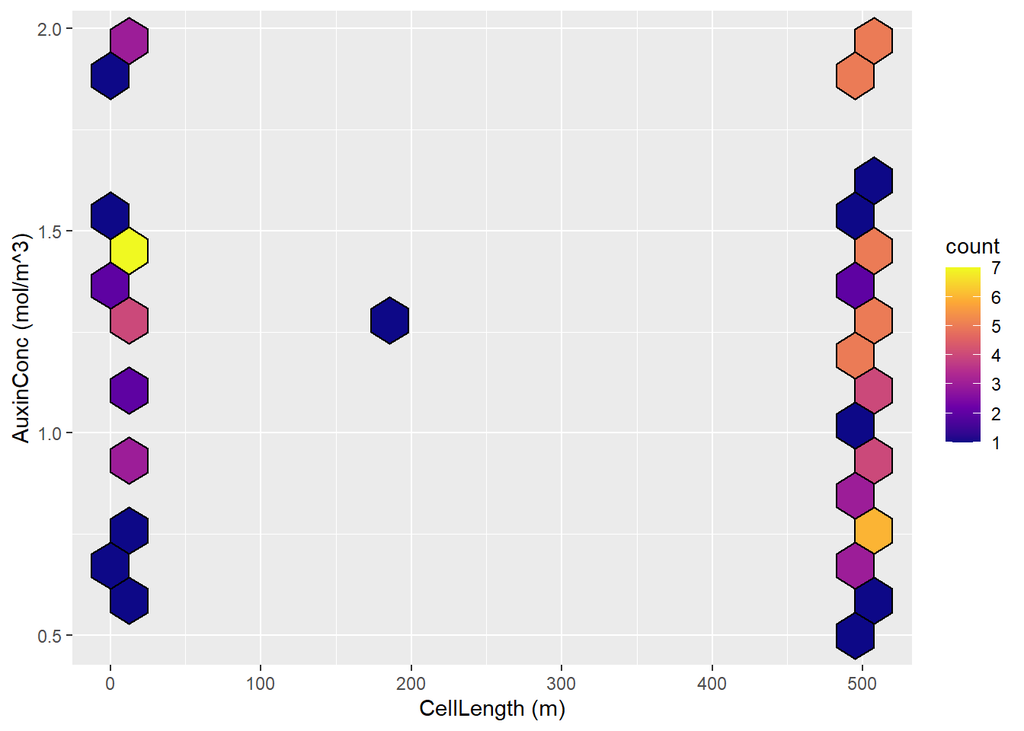

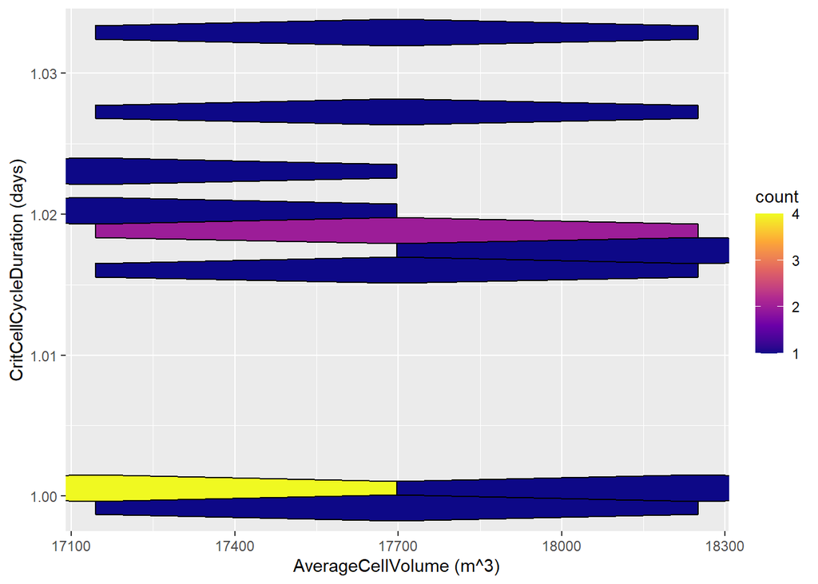

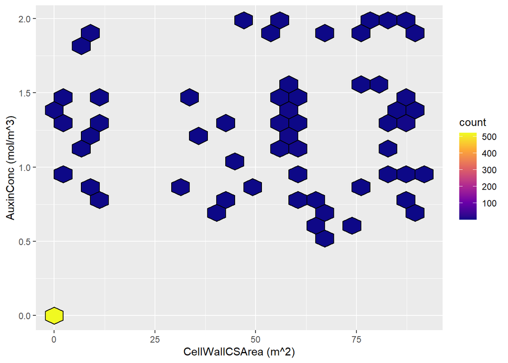

[figure not shown]

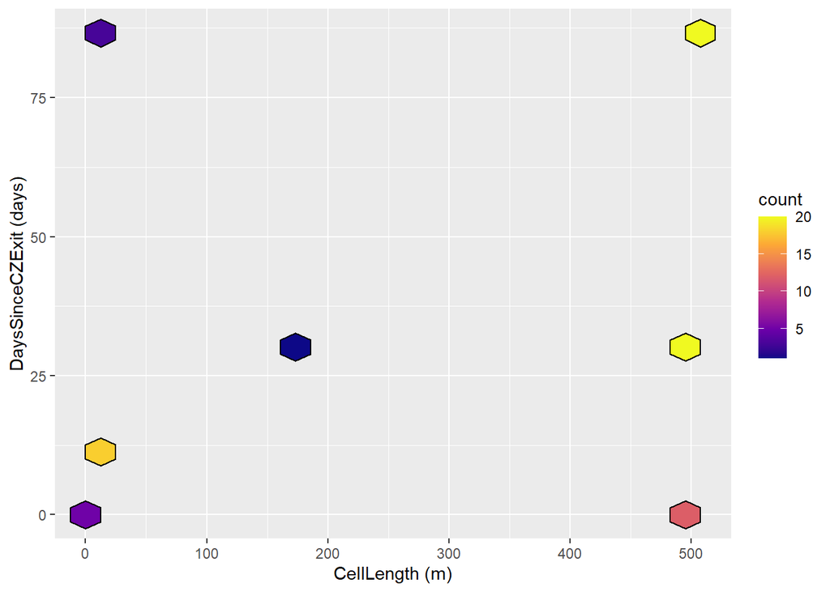

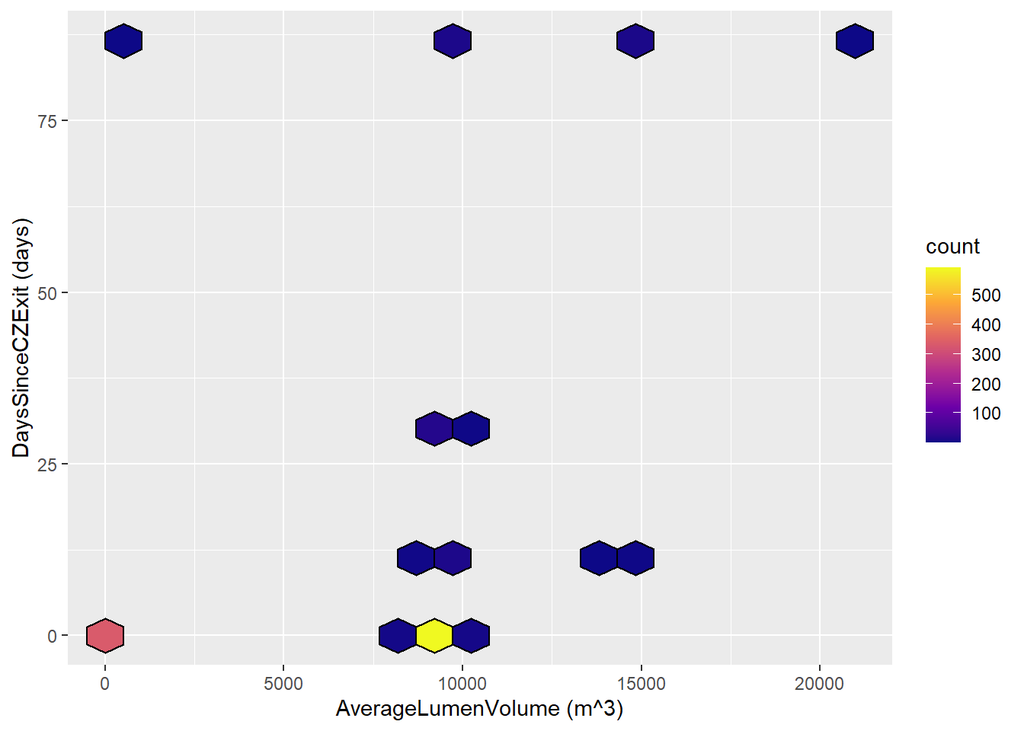

[3 more figures not shown]

```r
for (pair in plot_pairs) {
  x_var <- pair[1]
  y_var <- pair[2]

  # Create the ggplot object
  pp <- ggplot(data, aes_string(x = x_var, y = y_var)) +
    geom_hex(bins = 20, size = 0.5, color = "black") +
    scale_fill_viridis_c(option = "C") +
    labs(x = paste(x_var, units_dict[[x_var]], sep = " "),
         y = paste(y_var, units_dict[[y_var]], sep = " "))

  # Print the plot to the R Markdown document
  print(pp)

  # Save the static image
  image_file <- paste0("markdown_plots/2Dplot_", x_var, "_vs_", y_var, ".png")

  # Use ggsave to save the plot
  ggsave(image_file, plot = pp, width = 8, height = 6, dpi = 300)  # Save the plot with high resolution
}
```

## Conclusion

This script provides a comprehensive approach to visualizing cellular automata data and generating insightful scatter plots for various cellular parameters. By organizing the code into sections and functions, the script enhances readability and maintainability, enabling further analysis and visualization as needed.